# **Predicting High Volatility Periods in the S&P 500**

Spring 2026 Data Science Project

Group Members:

- Daniel Alvarado - exchange student. UID:122291461
- Felix Ozpaker. UID: 120829642
- Adithi Sathish - exchange student. UID: 122360983
- Evan Dye. UID: 120934391

**Contributions**

- Daniel Alvarado: Worked on mainly exploratory data analysis and primary analysis. (A, C, D, E)
- Felix Ozpaker: Worked on mainly data curation and exploratory data analysis. (A, B, C)
- Adithi Sathish: Worked on mainly data curation, visualization, result analysis, and conclusion. (A, B, F)
- Evan Dye: Worked on mainly introduction, visualization, result analysis, conclusion, and final tutorial report creation. (A, F, G)

# **Introduction**

While the stock market can be a lucrative way to make money, it can also be incredibly risky for the average person who has limited capital. Predicting the direction of stock markets is a very difficult task. However, the volatility of stocks follows a more predictable pattern due to a behavior known as volatility clustering.

Our goal is to predict periods of higher volatility for individual stocks in the S&P 500 before they occur. This is an important task, since knowing when periods of high volatility will occur allows investors to limit exposure to risky periods, protecting them from potentially large losses in a short period of time.

# **Data Curation**

**Dataset:** https://www.kaggle.com/datasets/jacksaleeby/global-stock-market-indices-4-6m-rows/data [we are using the SP500_USA.csv dataset specifically.]

**Info About Volatility Clustering:** https://en.wikipedia.org/wiki/Volatility_clustering

```python
import pandas as pd
import numpy as np
import matplotlib.pyplot as plt
import seaborn as sns
from scipy import stats
from scipy.stats import levene, binomtest
from sklearn.ensemble import RandomForestClassifier
from sklearn.metrics import accuracy_score, precision_score, recall_score, f1_score, mean_absolute_error, mean_squared_error, roc_curve, roc_auc_score, confusion_matrix, r2_score
```

```python
#df = pd.read_csv("/SP500_USA.csv")
```

```python
df= pd.read_csv('SP500_USA.csv')
```

Now that we have imported the dataset, let's look at the features of the dataframe, in order to analyze what cleaning/processing may be necessary.

```python
df.head()
```

|  | Ticker | Date | Open | High | Low | Close | Adj Close | Volume |
| --- | --- | --- | --- | --- | --- | --- | --- | --- |
| 0 | A | 2000-01-03 | 47.07 | 47.18 | 40.27 | 43.04 | 43.04 | 4674353 |
| 1 | A | 2000-01-04 | 40.72 | 41.17 | 38.70 | 39.75 | 39.75 | 4765083 |
| 2 | A | 2000-01-05 | 39.60 | 39.75 | 36.05 | 37.28 | 37.28 | 5758642 |
| 3 | A | 2000-01-06 | 36.83 | 37.06 | 34.74 | 35.86 | 35.86 | 2534434 |
| 4 | A | 2000-01-07 | 35.30 | 39.41 | 35.27 | 38.85 | 38.85 | 2819626 |

As seen above, this dataset collects and observes individual stock data from USA's S&P 500 index. The open and close columns respectively indicate the price of a stock when the market opens and closes daily. High and low indicate the highest and lowest stock prices on a particular day. Adjusted close accounts for stock splits and dividends, and volume indicates the number of shares traded on the day.

In order to properly calculate volatility, we must first create a returns column.

```python
df['Returns'] = df.groupby('Ticker')['Adj Close'].pct_change()
df = df.dropna()
df = df.copy()
df.head()
```

|  | Ticker | Date | Open | High | Low | Close | Adj Close | Volume | Returns |
| --- | --- | --- | --- | --- | --- | --- | --- | --- | --- |
| 1 | A | 2000-01-04 | 40.72 | 41.17 | 38.70 | 39.75 | 39.75 | 4765083 | -0.076441 |
| 2 | A | 2000-01-05 | 39.60 | 39.75 | 36.05 | 37.28 | 37.28 | 5758642 | -0.062138 |
| 3 | A | 2000-01-06 | 36.83 | 37.06 | 34.74 | 35.86 | 35.86 | 2534434 | -0.038090 |
| 4 | A | 2000-01-07 | 35.30 | 39.41 | 35.27 | 38.85 | 38.85 | 2819626 | 0.083380 |
| 5 | A | 2000-01-10 | 41.24 | 41.62 | 40.38 | 41.21 | 41.21 | 2148446 | 0.060746 |

Now lets look at the data types

```python
df.dtypes
```

```
Ticker        object
Date          object
Open         float64
High         float64
Low          float64
Close        float64
Adj Close    float64
Volume         int64
Returns      float64
dtype: object
```

As seen above, the Date column is stored as an object (string) rather than a datetime type. We will convert it to datetime so that we can extract time-based features like month, which will be useful during our analysis.

```python
df['Date'] = pd.to_datetime(df['Date'])
df['Month'] = df['Date'].dt.month
df = df.dropna()
df = df.copy()
```

After parsing, the dataframe has been cleaned and is ready for feature engineering. The Date column is now a proper datetime object, Returns captures each stock's daily percent change, and all NaN rows have been removed.

## **Feature Engineering & Data Visualizations**

Our goal is to predict high volatility periods. To do this, we will engineer a set of features that capture volatility relevant information from each stock's recent history. All features will be computed per ticker.

We compute rolling standard deviations of returns at three different windows: 5, 20, and 60 trading days to capture short, medium, and long term volatility regimes. The 20-day window (1 calendar month) is the industry standard measure of volatility

Since we do this using the groupby method, each stock's volatility is calculated independently, meaning a price spike in AAPL won't affect other stocks such as MSFT. The first n-1 days of each tickers history are dropped, since a n-day window requires at minimum n observations (days) to produce a valid rolling average.

A high volatility value on a given day means the stock has been swinging heavily over the past month, with a low value representing the opposite - the stock has been trading steadily.

This column will become the foundation for our prediction target in the later sections.

```python
df['Volatility_5d'] = (df.groupby('Ticker')['Returns'].transform(lambda x: x.rolling(window=5).std()))
df['Volatility_20d'] = (df.groupby('Ticker')['Returns'].transform(lambda x: x.rolling(window=20).std()))
df['Volatility_60d'] = (df.groupby('Ticker')['Returns'].transform(lambda x: x.rolling(window=60).std()))

df = df.dropna()
df = df.copy()
```

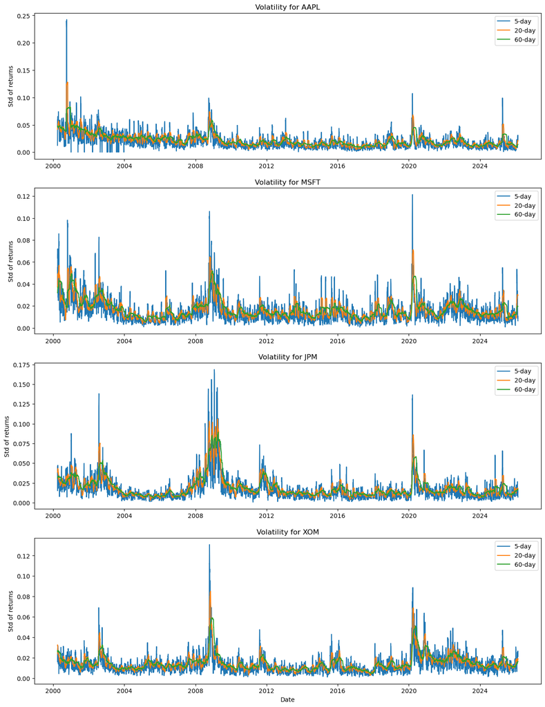

```python
tickers_to_plot = ["AAPL", "MSFT", "JPM", "XOM"]
vol_cols = ['Volatility_5d', 'Volatility_20d', 'Volatility_60d']

figure, axis = plt.subplots(nrows=4, ncols=1, figsize = (15,20))

for i, ticker in enumerate(tickers_to_plot):
  subset = df[df['Ticker'] == ticker].sort_values('Date')

  axis[i].plot(subset['Date'], subset['Volatility_5d'], label='5-day')
  axis[i].plot(subset['Date'], subset['Volatility_20d'], label='20-day')
  axis[i].plot(subset['Date'], subset['Volatility_60d'], label='60-day')
  axis[i].set_title(f"Volatility for {ticker}")
  axis[i].set_ylabel('Std of returns')
  axis[i].legend()

plt.xlabel('Date')
plt.show()
```

As seen in the plot above, volatility is not constant over time, it clusters into distinct high risk periods, some of which aligning with major real world events. As seen in the graph, the 2008 financial crisis and COVID-19 crash of 2020 both produced sharp spikes across all 4 tickers. We also see that the shorter the window, the more noisy it is.

We will define a high volatility day as any day where the next day's 5-day rolling volatility exceeds the 80th percentile of that column across all stocks and all previous dates. By shifting the target forward by one day, the model will be forced to predict future volatility rather than describing current volatility which helps avoid data leakage. Days above the threshold (high volatility) will be labeled as 1, and days below (low volatility) will be labeled as 0.

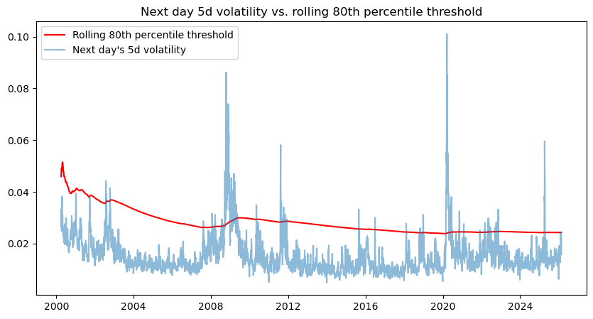

```python
df = df.sort_values('Date')
df['target_vol'] = df.groupby('Ticker')['Volatility_5d'].shift(-1)
df['threshold'] = df['target_vol'].expanding().quantile(0.80)


df['target_high_vol'] = (df['target_vol'] > df['threshold']).astype(int)
df = df.dropna(subset=['target_vol']).copy()

plot_df = df.groupby('Date')[['target_vol', 'threshold']].median().reset_index()
figure, ax = plt.subplots(figsize = (10,5))
ax.plot(plot_df['Date'], plot_df['threshold'], color='red', label='Rolling 80th percentile threshold')
ax.plot(plot_df['Date'], plot_df['target_vol'], label = "Next day's 5d volatility", alpha=0.5)
plt.title('Next day 5d volatility vs. rolling 80th percentile threshold')
plt.legend()
plt.show()
```

Additionally, a well-known phenomenon in finance is called "volatility clustering", which is the tendency for large price changes to be followed by larger changes. To capture this, we will create a lagged absolute returns column. These features will allow our model to look back at the magnitude of price swings from 1, 5, and 10 days ago.

```python
df['abs_return'] = df['Returns'].abs()
for lag in [1, 5, 10]:
  df[f'abs_ret_lag_{lag}'] = df.groupby('Ticker')['abs_return'].shift(lag)

df = df.dropna()
df = df.copy()
df.head()
```

|  | Ticker | Date | Open | High | Low | Close | Adj Close | Volume | Returns | Month | Volatility_5d | Volatility_20d | Volatility_60d | target_vol | threshold | target_high_vol | abs_return | abs_ret_lag_1 | abs_ret_lag_5 | abs_ret_lag_10 |
| --- | --- | --- | --- | --- | --- | --- | --- | --- | --- | --- | --- | --- | --- | --- | --- | --- | --- | --- | --- | --- |
| 2604474 | WHR | 2000-04-12 | 28.28 | 29.63 | 28.28 | 29.35 | 29.35 | 426600 | 0.041889 | 4 | 0.021025 | 0.032399 | 0.035158 | 0.021072 | 0.048216 | 0 | 0.041889 | 0.003185 | 0.023150 | 0.049206 |
| 239059 | AVY | 2000-04-12 | 34.03 | 36.11 | 33.83 | 35.47 | 35.47 | 561900 | 0.038349 | 4 | 0.031039 | 0.038274 | 0.035711 | 0.027002 | 0.048205 | 0 | 0.038349 | 0.066833 | 0.016970 | 0.026316 |
| 1279268 | IBM | 2000-04-12 | 58.93 | 58.93 | 55.02 | 56.04 | 56.04 | 9293919 | -0.047101 | 4 | 0.018789 | 0.028292 | 0.025232 | 0.019196 | 0.048195 | 0 | 0.047101 | 0.022603 | 0.031491 | 0.028500 |
| 2502041 | USB | 2000-04-12 | 10.56 | 11.54 | 10.56 | 11.14 | 11.14 | 7165500 | 0.048964 | 4 | 0.034367 | 0.044799 | 0.039416 | 0.046331 | 0.048185 | 0 | 0.048964 | 0.069486 | 0.018682 | 0.007194 |
| 2539603 | VRTX | 2000-04-12 | 22.84 | 24.00 | 21.88 | 21.88 | 21.88 | 423800 | -0.035699 | 4 | 0.096053 | 0.082931 | 0.079807 | 0.043666 | 0.048174 | 0 | 0.035699 | 0.048238 | 0.137127 | 0.058802 |

Volatility often spikes when a stock's price deviates significant from its recent trend or when trading volume is high. To see how these affect volatility, we will compute price to moving average ratios and volume intensity metrics. These will be useful later on in the ML portion of the project, as they can give the model signals about whether a stock is entering a high volatility period or experiencing any abnormal behaviour.

```python
df['moving_avg_20d'] = df.groupby('Ticker')['Adj Close'].transform(lambda x: x.rolling(20).mean())
df['price_to_ma'] = df['Adj Close'] / df['moving_avg_20d']

df['vol_ma_20'] = df.groupby('Ticker')['Volume'].transform(lambda x : x.rolling(20).mean())
df['vol_ratio'] = df['Volume'] / df['vol_ma_20']

df = df.dropna()
df = df.copy()
```

# **Exploratory Data Analysis**

Having curated our dataset and engineered features to capture price swings, we now pivot to Exploratory Data Analysis (EDA). Our goal here is not to just describe the data, but to test our assumptions about how the S&P 500 behaves. We want to identify the underlying characteristics of market volatility: whether it exhibits seasonality, whether it is symmetrically distributed, and other related questions.

## **1. Are the monthly returns distributions equal across all months?**

A long standing idea in finance is that certain months, such as January, September, or October, exhibit distinct market bahavior. We want to know: Are some months inherently more volatile than others? If so, what months, as the time of year could be a crucial signal for out prediction model.

We will use the Kruskal-Wallis H-test.

More information about Kruskal-Wallis H-test: https://en.wikipedia.org/wiki/Kruskal%E2%80%93Wallis_test

Documentation of Kruskal-Wallis H-test: https://docs.scipy.org/doc/scipy/reference/generated/scipy.stats.kruskal.html

To test this we will propose these hypotheses:

- Null Hypothesis (H0): monthly return distributions are the same accross the different months
- Alternate Hypothesis (H1): at least one month has a different distribution

```python
groups = [df[df['Month']==m]['Returns'].dropna() for m in range(1,13)]
h_stat,p_value=stats.kruskal(*groups)
print(f'P-value is equal to: {p_value} ')
if p_value <0.05:
  print('Reject H0')
else:
  print('Fail to reject H0')
```

```
P-value is equal to: 3.941794262423648e-251
Reject H0
```

With a p-value of approximately 3.94e-251, which is effectively zero, we reject the null hypothesis with extreme confidence. This result indicates that at least one month has significantly different distribution of daily returns, suggesting that seasonal factors may play a measurable role in market behaviour.

To see the spread of these returns, we use a boxplot grouped by month. This allows us to visualize the range of outcomes investors face throughout the year.

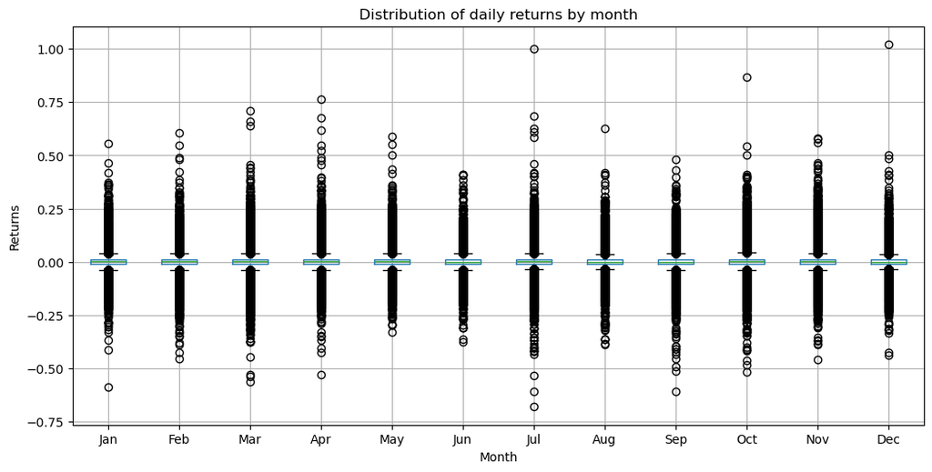

```python
fig, ax = plt.subplots(figsize=(12,6))
df.boxplot(column='Returns', by='Month', ax=ax)
month_names = ['Jan','Feb','Mar','Apr','May','Jun','Jul','Aug','Sep','Oct','Nov','Dec']
plt.xticks(ticks=range(1,13), labels=month_names)
plt.suptitle('')
plt.title('Distribution of daily returns by month')
plt.ylabel('Returns')
plt.xlabel('Month')
plt.show()
```

The boxplot above shows the distribution of daily distributions grouped by month using the available years in the dataset. While the median returns hover near 0.00%, the volatility profile tells a different story.

Instead of seeing uniform behaviour, we notice that July stands out for its extreme outliers. These circles represent days where the market experiences significant shocks that fall far outside the normal range of trading.

## **2. Do high volatility periods have greater return variance than low volatility periods?**

We must confirm that our "High Volatility" label actually points to a different kind of market risk. If these periods don't actually show bigger price moves, our model may not be as useful.

We will use Levene's Test, and let alpha be 0.05.

- Null Hypothesis (H0): The variance of returns is the same during high and low volatility periods
- Alternative Hypothesis (H1): High volatility periods have significantly greater return variance

More about Levene Test:

Documentation - https://docs.scipy.org/doc/scipy/reference/generated/scipy.stats.levene.html

More Info - https://en.wikipedia.org/wiki/Levene%27s_test

```python
high_vol_returns = df[df['target_high_vol'] == 1]['Returns']
low_vol_returns = df[df['target_high_vol'] == 0]['Returns']

lev = levene(high_vol_returns, low_vol_returns)
print(f"P-value: {lev.pvalue:.5e}")
```

```
P-value: 0.00000e+00
```

The p-value is 0.0, smaller than Pythons minimum representable float. This is an overwhelmingly strong result, as it shows we can reject the null hypothesis with complete and extreme confidence and conclude that return variance is significantly greater during high-volatility periods than during low volatility periods.

As seen in the below histogram, the Low Volatility days (blue) are tightly clustered around 0. In contrast the High Volatiltiy days (orange) display a much flatter and wider distribution.

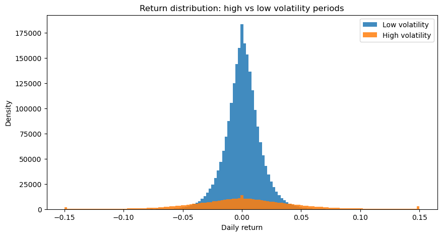

```python
figure, ax = plt.subplots(figsize=(10,5))
ax.hist(low_vol_returns.clip(-0.15, 0.15), bins=125, alpha = 0.85, label='Low volatility')
ax.hist(high_vol_returns.clip(-0.15, 0.15), bins=125, alpha = 0.85, label='High volatility')

plt.legend()
plt.title('Return distribution: high vs low volatility periods')
plt.ylabel('Density')
plt.xlabel('Daily return')
plt.show()
```

## **3. Are positive extremes more frequent than negative extemes?**

Standard finance theories often assume stock prices move in a balanced bell curve. We want to know if this is true or if the S&P 500 has bias. Specifically, we are testing if extreme "positive" days happen more often than extreme "negative" days.

We will use a Binomial test and let alpha be 0.05.

- Null Hypothesis (H0): Number of extreme positives = Number of extreme negatives
- Alternative Hypothesis (H1): Number of extreme positives > Number of extreme negatives

```python
returns = df["Returns"]
std = returns.std()
extreme_pos = returns[returns > (3*std)]
extreme_neg = returns[returns < (-3*std)]
num_pos_extremes = len(extreme_pos)
num_neg_extremes = len(extreme_neg)

total_extremes = num_pos_extremes + num_neg_extremes

bin_test = binomtest(num_pos_extremes, total_extremes, 0.5, alternative='greater')
display(bin_test.pvalue)
```

```
2.293596501539681e-67
```

The p-value is ~2.3e-67, which means that if the null hypothesis were true, the probability that we randomly observed a difference like this would be effectively zero. Since our p-value is significantly below the alpha of 0.05, we reject the null hypothesis, so we conclude that there is a statistically significant difference between the frequency of positive and negative extremes (positive extremes are more common than negative ones).

The following code and graphs are relevant plots to the hypothesis test.

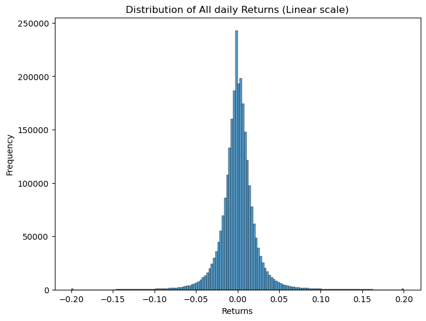

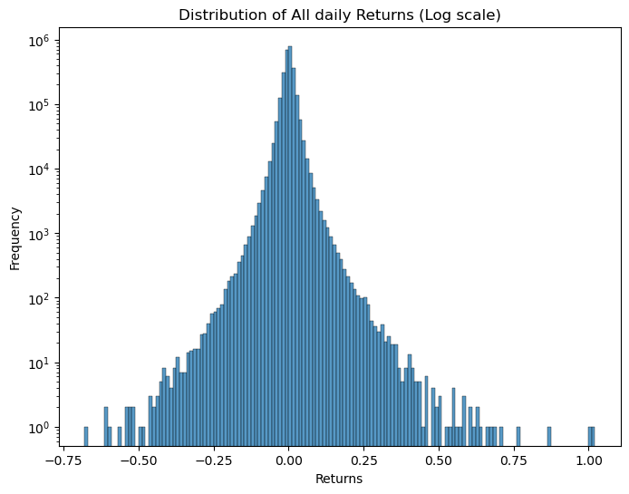

```python
df['Returns'] = df.groupby('Ticker')['Adj Close'].pct_change()

plt.figure(figsize=(8,6))
sns.histplot(df['Returns'].clip(-0.2, 0.2), bins = 150)
plt.yscale('linear')
plt.title('Distribution of All daily Returns (Linear scale)')
plt.xlabel('Returns')
plt.ylabel('Frequency')
plt.show()


plt.figure(figsize=(8,6))
sns.histplot(df['Returns'], bins = 150)
plt.yscale('log')
plt.title('Distribution of All daily Returns (Log scale)')
plt.xlabel('Returns')
plt.ylabel('Frequency')
plt.show()
```

Conclusion: This histogram displays how frequent various daily returns are. It shows that returns are bell shaped, but heavily centered about 0.00, meaning most days see very little change.

However, by using a logarithmic scale, we can see fat tails on both sides. This proves that extreme jumps happen more often than a standard bell curve would suggest. To summarize, typically the market is still, but when it moves, it moves further than expected.

# **Primary Analysis**

Our research question is if we can predict when a stock is going to enter a high volatility period beforehand. We will address this as a binary classification problem: "given today's stock information can we predict if tomorrow will be highly volatile?".

In order to do that we will use a Random Forest Classifier and compare it to a naive baseline to measure how much the model improves.

Since our data is time, it cannot be splitted randomly; therefore, we will train our data before 2022 and test with the data after 2022

Documentation and more information about Random Forest Classifiers: https://scikit-learn.org/stable/modules/generated/sklearn.ensemble.RandomForestClassifier.html

```python
feature_cols=['Volatility_5d', 'Volatility_60d','abs_ret_lag_1', 'abs_ret_lag_5','abs_ret_lag_10','price_to_ma','vol_ratio','Month']

splitDate = pd.Timestamp('2022-01-01')

train_df=df[df['Date']<splitDate].copy()
test_df=df[df['Date']>=splitDate].copy()

X_train = train_df[feature_cols]
X_test = test_df[feature_cols]
y_train = train_df['target_high_vol']
y_test = test_df['target_high_vol']

print(f"Training set: {len(X_train):,} rows ({train_df['Date'].min().date()} to {train_df['Date'].max().date()})")
print(f"Test set: {len(X_test):,} rows ({test_df['Date'].min().date()} to {test_df['Date'].max().date()})")
```

```
Training set: 2,175,756 rows (2000-05-10 to 2021-12-31)
Test set: 484,916 rows (2022-01-03 to 2026-02-19)
```

Before training the Random Forest, we establish a baseline to know what we are actually beating. This naive baseline directly exploits the volatility clustering phenomenon. If our Random Forest cannot beat this rule, the additional features are not contributing real predictive value.

```python
naivePred=(test_df['Volatility_20d']>test_df['threshold']).astype(int)

baselineMetrics={'Accuracy':accuracy_score(y_test,naivePred),'Precision':precision_score(y_test,naivePred),'Recall':recall_score(y_test,naivePred),'F1':f1_score(y_test,naivePred)}

print("\nNaive Baseline Performance:")
for metric,value in baselineMetrics.items():
  print(f"{metric}:{value:.4f}")
```

```
Naive Baseline Performance:
Accuracy:0.8255
Precision:0.5438
Recall:0.5839
F1:0.5631
```

We will train a Random Forest with 200 estimators and a max_depth of 10. Making it more robust to noise and easier to understand it through feature importance.

```python
rf_model = RandomForestClassifier(n_estimators=200,max_depth=10,random_state=42,n_jobs=-1)
rf_model.fit(X_train, y_train)
rf_pred = rf_model.predict(X_test)
rf_prob = rf_model.predict_proba(X_test)[:,1]

rf_metrics={'Accuracy': accuracy_score(y_test,rf_pred),'Precision': precision_score(y_test,rf_pred),'Recall': recall_score(y_test,rf_pred),'F1': f1_score(y_test,rf_pred),'ROC-AUC': roc_auc_score(y_test,rf_prob)}
rf_confusion = confusion_matrix(y_test,rf_pred)

print("Random Forest Performance")
for metric,value in rf_metrics.items():
  print(f"{metric}:{value:.4f}")
```

```
Random Forest Performance
Accuracy:0.9019
Precision:0.8965
Recall:0.5545
F1:0.6852
ROC-AUC:0.9466
```

We will summarize the performance of both in a table, in order to see if the Random Forest beats the naive baseline. If not it will mean that the features are not adding any real value.

```python
summary=pd.DataFrame({'Naive Baseline':{**baselineMetrics,'ROC-AUC':np.nan},'Random Forest': rf_metrics,}).T.round(4)
print("model comparison")
display(summary)

acc_gain = rf_metrics['Accuracy']- baselineMetrics['Accuracy']
f1_gain = rf_metrics['F1'] - baselineMetrics['F1']
print(f"Accuracy gain: +{acc_gain:.4f}")
print(f"F1 score: +{f1_gain:.4f}")
```

```
model comparison
```

|  | Accuracy | Precision | Recall | F1 | ROC-AUC |
| --- | --- | --- | --- | --- | --- |
| Naive Baseline | 0.8255 | 0.5438 | 0.5839 | 0.5631 | NaN |
| Random Forest | 0.9019 | 0.8965 | 0.5545 | 0.6852 | 0.9466 |

```
Accuracy gain: +0.0763
F1 score: +0.1221
```

We can see that the random forest improves the metrics of the naive analysis. Being the most important the gain of +12% in the F1 Score. While it can seem small, when analysing the market this percentage is a very significant gain.

Next, we will extract feature importance from the Random Forest to see what contributed the most. Connecting to our Data exploration, the features selected should align with the patterns we discovered

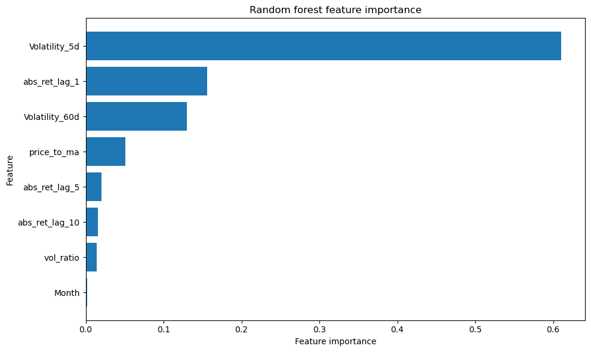

|  | feature | importance |
| --- | --- | --- |
| 0 | Volatility_5d | 0.610392 |
| 2 | abs_ret_lag_1 | 0.155921 |
| 1 | Volatility_60d | 0.130214 |
| 5 | price_to_ma | 0.051048 |
| 3 | abs_ret_lag_5 | 0.020570 |
| 4 | abs_ret_lag_10 | 0.015835 |
| 6 | vol_ratio | 0.014237 |
| 7 | Month | 0.001783 |

```python
important_df=pd.DataFrame({'feature':feature_cols,'importance':rf_model.feature_importances_}).sort_values('importance',ascending=False)

fig,ax=plt.subplots(figsize=(10,6))
ax.barh(important_df['feature'],important_df['importance'])
ax.invert_yaxis()
ax.set_xlabel('Feature importance')
ax.set_ylabel('Feature')
ax.set_title('Random forest feature importance')
plt.tight_layout()
plt.show()
display(important_df)
```

Looking at the graph of the most important features we can see that Volatility_5d is by far the most important feature, confirming that recent volatility is the strongest predictor. Alingning with the data exploration

On the other hand, Month contributes almost nothing, suggesting once volatility is available, the month adds no extra predictive value.

# **Visualization**

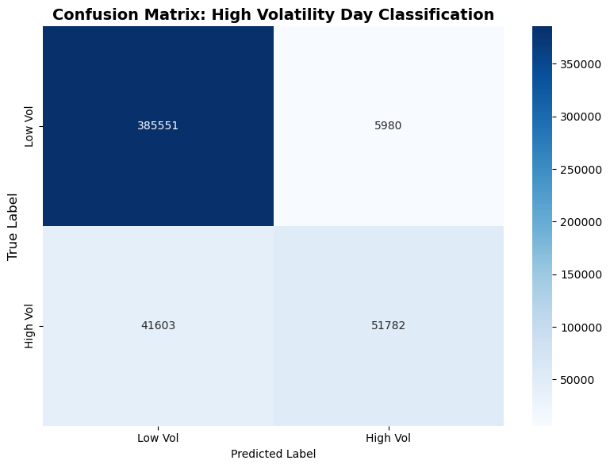

```
True Positives (caught high-vol days): 51,782 out of 93,385 (55.5%)
False Negatives (missed high-vol days): 41,603
```

```python
fig, ax = plt.subplots(figsize=(8, 6))
sns.heatmap(rf_confusion, annot=True, fmt='d', cmap='Blues', cbar=True,
            xticklabels=['Low Vol', 'High Vol'],
            yticklabels=['Low Vol', 'High Vol'])
ax.set_xlabel('Predicted Label')
ax.set_ylabel('True Label', fontsize=12)
ax.set_title('Confusion Matrix: High Volatility Day Classification', fontsize=14, fontweight='bold')
plt.tight_layout()
plt.show()

tn, fp, fn, tp = rf_confusion.ravel()
print(f"\nTrue Positives (caught high-vol days): {tp:,} out of {tp+fn:,} ({tp/(tp+fn)*100:.1f}%)")
print(f"False Negatives (missed high-vol days): {fn:,}")
```

Our confusion matrix shows there is strong performance on low-volatility days (~99% accuracy) but poor detection of high-volatility days (only ~51,000 out of 93,385 caught, or ~55% recall). This imbalance might suggest the model is simply predicting "low volatility" for most points.

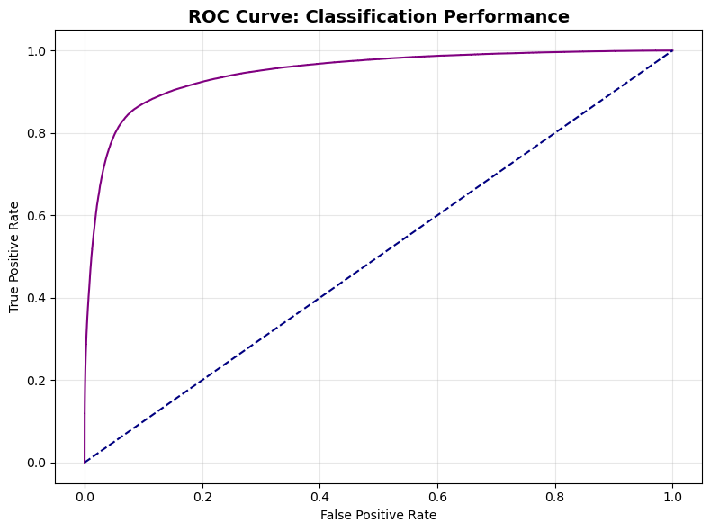

```
ROC-AUC: 0.9466
```

```python
fpr, tpr, _ = roc_curve(y_test, rf_prob)
roc_auc = roc_auc_score(y_test, rf_prob)

fig, ax = plt.subplots(figsize=(8, 6))
ax.plot(fpr, tpr, color='purple', label=f'ROC Curve (AUC = {roc_auc:.3f}')
ax.plot([0, 1], [0, 1], color='navy', linestyle='--', label='Random (AUC = 0.500)')
ax.set_xlabel('False Positive Rate')
ax.set_ylabel('True Positive Rate')
ax.set_title('ROC Curve: Classification Performance', fontsize=14, fontweight='bold')
ax.grid(True, alpha=0.3)
plt.tight_layout()
plt.show()

print(f"ROC-AUC: {roc_auc:.4f}")
```

The ROC curve allows us to visualize the tradeoffs between better recall and increased amounts of false positives. The ROC curve deviates significantly from the diagonal line, with an ROC_AUC of over .9 showing that it is quite good at distinguishing low and high volatility days.

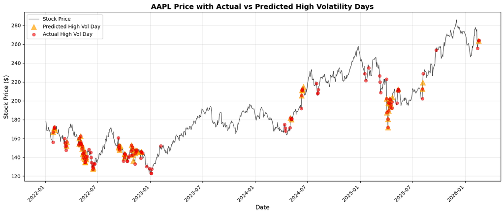

```
Red dots = actual high-vol days, Orange triangles = our predictions
```

```python
aapl_mask = test_df['Ticker'] == 'AAPL'
aapl_test = test_df[aapl_mask].copy().sort_values('Date').reset_index(drop=True)

aapl_pred = rf_pred[aapl_mask.values]
aapl_test['pred_high_vol'] = aapl_pred

fig, ax = plt.subplots(figsize=(14, 6))
ax.plot(aapl_test['Date'], aapl_test['Adj Close'],
        color='black', linewidth=1, alpha=0.7, label='Stock Price')
high_vol_pred = aapl_test[aapl_test['pred_high_vol'] == 1]
ax.scatter(high_vol_pred['Date'], high_vol_pred['Adj Close'],
           color='orange', s=120, alpha=0.7, zorder=4,
           marker='^', edgecolors='darkorange', linewidth=0.5,
           label='Predicted High Vol Day')

high_vol_actual = aapl_test[aapl_test['target_high_vol'] == 1]
ax.scatter(high_vol_actual['Date'], high_vol_actual['Adj Close'],
           color='red', s=40, alpha=0.6, zorder=5,
           edgecolors='darkred', linewidth=0.5,
           label='Actual High Vol Day')

ax.set_xlabel('Date', fontsize=12)
ax.set_ylabel('Stock Price ($)', fontsize=12)
ax.set_title('AAPL Price with Actual vs Predicted High Volatility Days',
             fontsize=14, fontweight='bold')
ax.legend(loc='upper left')
ax.grid(True, alpha=0.3)
plt.xticks(rotation=45, ha='right')
plt.tight_layout()
plt.show()

print("Red dots = actual high-vol days, Orange triangles = our predictions")
```

# **Insights and Conclusion**

Our analysis shows that market volatility is partially predictable through machine learning. We learnt the following:

For investors, what would this spell? We came to the following conclusions:

1. Volatility is easier to predict than price direction in the market.
2. Recent behaviour and trends are the most effective early warnings.
3. Accurately predicting volatility for 90% of the days allows us to reduce exposure.
4. Our recall score of 55% means we miss 45% of high volatility days, which means the times when traders lose the most are often unaccounted for by our model.

**So, can we predict when the market will be volatile?**

Yes, we are now able to do so better than random guessing, but not perfectly. We achieved 90% accuracy demonstrating that volatility clustering is possible for risk management.